# Bellabeat - case study

Manpreet

2022-08-20

[figure not shown]

#Bellabeat

##Overview##

*About Client*

Bellabeat, a high-tech company that manufactures health-focused smart products. Sršen used her background as an artist to develop beautifully designed technology that informs and inspires women around the world. Collecting data on activity, sleep, stress, and reproductive health has allowed Bellabeat to empower women with knowledge about their own health and habits. Since it was founded in 2013, Bellabeat has grown rapidly and quickly positioned itself as a tech-driven wellness company for women.

**Products** *Bellabeat app (analyses custormer’s essentials and helps in making healthy decisons)* Leaf, a tracking jewellery *spring, a tracking bottle to measure ones’s water in-take* Time, a tracking watch

*stakeholders* 1.Urška Sršen: Bellabeat’s cofounder and Chief Creative Officer

2.Sando Mur: Mathematician and Bellabeat’s cofounder; key member of the Bellabeat executive team

3.Bellabeat marketing analytics team

##Problem_statement(ASK) 1.What are some trends in smart device usage? (how well these devices fit-in and helps) 2.How could these trends apply to Bellabeat customers? (beased upon the fit and finding the misfit, certain strategy should be suggested) 3.How could these trends help influence Bellabeat marketing strategy?

##Prepare *Data Source* *Kaggle open dataset called [FitBit Fitness Tracker Data](https://www.kaggle.com/datasets/arashnic/fitbit)

*Containig 18.csv files in Long format of ABOUT 30 Fitbit users.

*ROCCC*

*Reliable: The data is not reliable as there are only 30 participants so it could be incomplete and biased.

*Original: The data is not Original as its collected from third party data collector

*Comprehensive: The usage of the product could be tracked with the data as it captures minute-level output for physical activity, heart rate, and sleep monitoring. But the small sample size is a questionable parameter.

*Cited: Due to low credibility and high generality, it very difficult to have any business utility, though perfect for learning and education purposes so, it didn’t mentioned anywhere.

*Data Cleaning*

A primary look reveals :

*data is too big for Excel, so using R.

**loading packages**

```r
library(tidyverse)
library(skimr)
library(lubridate)
library(janitor)
library(here)
library(readr)
```

since i have already installed the above packages so, avoid this time.

*Import files*

```r
dailyActivity_merged <- read_csv("Fitabase Data 4.12.16-5.12.16/dailyActivity_merged.csv")
dailyCalories_merged <- read_csv("Fitabase Data 4.12.16-5.12.16/dailyCalories_merged.csv")
dailyIntensities_merged <- read_csv("Fitabase Data 4.12.16-5.12.16/dailyIntensities_merged.csv")
dailySteps_merged <- read_csv("Fitabase Data 4.12.16-5.12.16/dailySteps_merged.csv")
heartrate_seconds_merged <- read_csv("Fitabase Data 4.12.16-5.12.16/heartrate_seconds_merged.csv")
sleepDay_merged <- read_csv("Fitabase Data 4.12.16-5.12.16/sleepDay_merged.csv")
weightLogInfo_merged <- read_csv("Fitabase Data 4.12.16-5.12.16/weightLogInfo_merged.csv")
```

*knowing the data well*

```r
head(dailyActivity_merged)
```

```
## # A tibble: 6 × 15
##       Id Activ…¹ Total…² Total…³ Track…⁴ Logge…⁵ VeryA…⁶ Moder…⁷ Light…⁸ Seden…⁹
##    <dbl> <chr>     <dbl>   <dbl>   <dbl>   <dbl>   <dbl>   <dbl>   <dbl>   <dbl>
## 1 1.50e9 4/12/2…   13162    8.5     8.5        0    1.88   0.550    6.06       0
## 2 1.50e9 4/13/2…   10735    6.97    6.97       0    1.57   0.690    4.71       0
## 3 1.50e9 4/14/2…   10460    6.74    6.74       0    2.44   0.400    3.91       0
## 4 1.50e9 4/15/2…    9762    6.28    6.28       0    2.14   1.26     2.83       0
## 5 1.50e9 4/16/2…   12669    8.16    8.16       0    2.71   0.410    5.04       0
## 6 1.50e9 4/17/2…    9705    6.48    6.48       0    3.19   0.780    2.51       0
## # … with 5 more variables: VeryActiveMinutes <dbl>, FairlyActiveMinutes <dbl>,
## #   LightlyActiveMinutes <dbl>, SedentaryMinutes <dbl>, Calories <dbl>, and
## #   abbreviated variable names ¹ActivityDate, ²TotalSteps, ³TotalDistance,
## #   ⁴TrackerDistance, ⁵LoggedActivitiesDistance, ⁶VeryActiveDistance,
## #   ⁷ModeratelyActiveDistance, ⁸LightActiveDistance, ⁹SedentaryActiveDistance
## # ℹ Use `colnames()` to see all variable names
```

```r
head(dailyCalories_merged)
```

```
## # A tibble: 6 × 3
##           Id ActivityDay Calories
##        <dbl> <chr>          <dbl>
## 1 1503960366 4/12/2016       1985
## 2 1503960366 4/13/2016       1797
## 3 1503960366 4/14/2016       1776
## 4 1503960366 4/15/2016       1745
## 5 1503960366 4/16/2016       1863
## 6 1503960366 4/17/2016       1728
```

```r
head(dailyIntensities_merged)
```

```
## # A tibble: 6 × 10
##       Id Activ…¹ Seden…² Light…³ Fairl…⁴ VeryA…⁵ Seden…⁶ Light…⁷ Moder…⁸ VeryA…⁹
##    <dbl> <chr>     <dbl>   <dbl>   <dbl>   <dbl>   <dbl>   <dbl>   <dbl>   <dbl>
## 1 1.50e9 4/12/2…     728     328      13      25       0    6.06   0.550    1.88
## 2 1.50e9 4/13/2…     776     217      19      21       0    4.71   0.690    1.57
## 3 1.50e9 4/14/2…    1218     181      11      30       0    3.91   0.400    2.44
## 4 1.50e9 4/15/2…     726     209      34      29       0    2.83   1.26     2.14
## 5 1.50e9 4/16/2…     773     221      10      36       0    5.04   0.410    2.71
## 6 1.50e9 4/17/2…     539     164      20      38       0    2.51   0.780    3.19
## # … with abbreviated variable names ¹ActivityDay, ²SedentaryMinutes,
## #   ³LightlyActiveMinutes, ⁴FairlyActiveMinutes, ⁵VeryActiveMinutes,
## #   ⁶SedentaryActiveDistance, ⁷LightActiveDistance, ⁸ModeratelyActiveDistance,
## #   ⁹VeryActiveDistance
```

```r
head(dailySteps_merged)
```

```
## # A tibble: 6 × 3
##           Id ActivityDay StepTotal
##        <dbl> <chr>           <dbl>
## 1 1503960366 4/12/2016       13162
## 2 1503960366 4/13/2016       10735
## 3 1503960366 4/14/2016       10460
## 4 1503960366 4/15/2016        9762
## 5 1503960366 4/16/2016       12669
## 6 1503960366 4/17/2016        9705
```

```r
head(heartrate_seconds_merged)
```

```
## # A tibble: 6 × 3
##           Id Time                 Value
##        <dbl> <chr>                <dbl>
## 1 2022484408 4/12/2016 7:21:00 AM    97
## 2 2022484408 4/12/2016 7:21:05 AM   102
## 3 2022484408 4/12/2016 7:21:10 AM   105
## 4 2022484408 4/12/2016 7:21:20 AM   103
## 5 2022484408 4/12/2016 7:21:25 AM   101
## 6 2022484408 4/12/2016 7:22:05 AM    95
```

```r
head(sleepDay_merged)
```

```
## # A tibble: 6 × 5
##           Id SleepDay              TotalSleepRecords TotalMinutesAsleep TotalT…¹
##        <dbl> <chr>                             <dbl>              <dbl>    <dbl>
## 1 1503960366 4/12/2016 12:00:00 AM                 1                327      346
## 2 1503960366 4/13/2016 12:00:00 AM                 2                384      407
## 3 1503960366 4/15/2016 12:00:00 AM                 1                412      442
## 4 1503960366 4/16/2016 12:00:00 AM                 2                340      367
## 5 1503960366 4/17/2016 12:00:00 AM                 1                700      712
## 6 1503960366 4/19/2016 12:00:00 AM                 1                304      320
## # … with abbreviated variable name ¹TotalTimeInBed
```

```r
head(weightLogInfo_merged)
```

```
## # A tibble: 6 × 8
##           Id Date                  WeightKg Weight…¹   Fat   BMI IsMan…²   LogId
##        <dbl> <chr>                    <dbl>    <dbl> <dbl> <dbl> <lgl>     <dbl>
## 1 1503960366 5/2/2016 11:59:59 PM      52.6     116.    22  22.6 TRUE    1.46e12
## 2 1503960366 5/3/2016 11:59:59 PM      52.6     116.    NA  22.6 TRUE    1.46e12
## 3 1927972279 4/13/2016 1:08:52 AM     134.      294.    NA  47.5 FALSE   1.46e12
## 4 2873212765 4/21/2016 11:59:59 PM     56.7     125.    NA  21.5 TRUE    1.46e12
## 5 2873212765 5/12/2016 11:59:59 PM     57.3     126.    NA  21.7 TRUE    1.46e12
## 6 4319703577 4/17/2016 11:59:59 PM     72.4     160.    25  27.5 TRUE    1.46e12
## # … with abbreviated variable names ¹WeightPounds, ²IsManualReport
```

##Process First we have a quick look using

```r
str(dailyActivity_merged)
```

```
## spec_tbl_df [940 × 15] (S3: spec_tbl_df/tbl_df/tbl/data.frame)
##  $ Id                      : num [1:940] 1.5e+09 1.5e+09 1.5e+09 1.5e+09 1.5e+09 ...
##  $ ActivityDate            : chr [1:940] "4/12/2016" "4/13/2016" "4/14/2016" "4/15/2016" ...
##  $ TotalSteps              : num [1:940] 13162 10735 10460 9762 12669 ...
##  $ TotalDistance           : num [1:940] 8.5 6.97 6.74 6.28 8.16 ...
##  $ TrackerDistance         : num [1:940] 8.5 6.97 6.74 6.28 8.16 ...
##  $ LoggedActivitiesDistance: num [1:940] 0 0 0 0 0 0 0 0 0 0 ...
##  $ VeryActiveDistance      : num [1:940] 1.88 1.57 2.44 2.14 2.71 ...
##  $ ModeratelyActiveDistance: num [1:940] 0.55 0.69 0.4 1.26 0.41 ...
##  $ LightActiveDistance     : num [1:940] 6.06 4.71 3.91 2.83 5.04 ...
##  $ SedentaryActiveDistance : num [1:940] 0 0 0 0 0 0 0 0 0 0 ...
##  $ VeryActiveMinutes       : num [1:940] 25 21 30 29 36 38 42 50 28 19 ...
##  $ FairlyActiveMinutes     : num [1:940] 13 19 11 34 10 20 16 31 12 8 ...
##  $ LightlyActiveMinutes    : num [1:940] 328 217 181 209 221 164 233 264 205 211 ...
##  $ SedentaryMinutes        : num [1:940] 728 776 1218 726 773 ...
##  $ Calories                : num [1:940] 1985 1797 1776 1745 1863 ...
##  - attr(*, "spec")=
##   .. cols(
##   ..   Id = col_double(),
##   ..   ActivityDate = col_character(),
##   ..   TotalSteps = col_double(),
##   ..   TotalDistance = col_double(),
##   ..   TrackerDistance = col_double(),
##   ..   LoggedActivitiesDistance = col_double(),
##   ..   VeryActiveDistance = col_double(),
##   ..   ModeratelyActiveDistance = col_double(),
##   ..   LightActiveDistance = col_double(),
##   ..   SedentaryActiveDistance = col_double(),
##   ..   VeryActiveMinutes = col_double(),
##   ..   FairlyActiveMinutes = col_double(),
##   ..   LightlyActiveMinutes = col_double(),
##   ..   SedentaryMinutes = col_double(),
##   ..   Calories = col_double()
##   .. )
##  - attr(*, "problems")=<externalptr>
```

```r
str(dailyCalories_merged)
```

```
## spec_tbl_df [940 × 3] (S3: spec_tbl_df/tbl_df/tbl/data.frame)
##  $ Id         : num [1:940] 1.5e+09 1.5e+09 1.5e+09 1.5e+09 1.5e+09 ...
##  $ ActivityDay: chr [1:940] "4/12/2016" "4/13/2016" "4/14/2016" "4/15/2016" ...
##  $ Calories   : num [1:940] 1985 1797 1776 1745 1863 ...
##  - attr(*, "spec")=
##   .. cols(
##   ..   Id = col_double(),
##   ..   ActivityDay = col_character(),
##   ..   Calories = col_double()
##   .. )
##  - attr(*, "problems")=<externalptr>
```

```r
str(dailyIntensities_merged)
```

```
## spec_tbl_df [940 × 10] (S3: spec_tbl_df/tbl_df/tbl/data.frame)
##  $ Id                      : num [1:940] 1.5e+09 1.5e+09 1.5e+09 1.5e+09 1.5e+09 ...
##  $ ActivityDay             : chr [1:940] "4/12/2016" "4/13/2016" "4/14/2016" "4/15/2016" ...
##  $ SedentaryMinutes        : num [1:940] 728 776 1218 726 773 ...
##  $ LightlyActiveMinutes    : num [1:940] 328 217 181 209 221 164 233 264 205 211 ...
##  $ FairlyActiveMinutes     : num [1:940] 13 19 11 34 10 20 16 31 12 8 ...
##  $ VeryActiveMinutes       : num [1:940] 25 21 30 29 36 38 42 50 28 19 ...
##  $ SedentaryActiveDistance : num [1:940] 0 0 0 0 0 0 0 0 0 0 ...
##  $ LightActiveDistance     : num [1:940] 6.06 4.71 3.91 2.83 5.04 ...
##  $ ModeratelyActiveDistance: num [1:940] 0.55 0.69 0.4 1.26 0.41 ...
##  $ VeryActiveDistance      : num [1:940] 1.88 1.57 2.44 2.14 2.71 ...
##  - attr(*, "spec")=
##   .. cols(
##   ..   Id = col_double(),
##   ..   ActivityDay = col_character(),
##   ..   SedentaryMinutes = col_double(),
##   ..   LightlyActiveMinutes = col_double(),
##   ..   FairlyActiveMinutes = col_double(),
##   ..   VeryActiveMinutes = col_double(),
##   ..   SedentaryActiveDistance = col_double(),
##   ..   LightActiveDistance = col_double(),
##   ..   ModeratelyActiveDistance = col_double(),
##   ..   VeryActiveDistance = col_double()
##   .. )
##  - attr(*, "problems")=<externalptr>
```

```r
str(dailySteps_merged)
```

```
## spec_tbl_df [940 × 3] (S3: spec_tbl_df/tbl_df/tbl/data.frame)
##  $ Id         : num [1:940] 1.5e+09 1.5e+09 1.5e+09 1.5e+09 1.5e+09 ...
##  $ ActivityDay: chr [1:940] "4/12/2016" "4/13/2016" "4/14/2016" "4/15/2016" ...
##  $ StepTotal  : num [1:940] 13162 10735 10460 9762 12669 ...
##  - attr(*, "spec")=
##   .. cols(
##   ..   Id = col_double(),
##   ..   ActivityDay = col_character(),
##   ..   StepTotal = col_double()
##   .. )
##  - attr(*, "problems")=<externalptr>
```

```r
str(heartrate_seconds_merged)
```

```
## spec_tbl_df [2,483,658 × 3] (S3: spec_tbl_df/tbl_df/tbl/data.frame)
##  $ Id   : num [1:2483658] 2.02e+09 2.02e+09 2.02e+09 2.02e+09 2.02e+09 ...
##  $ Time : chr [1:2483658] "4/12/2016 7:21:00 AM" "4/12/2016 7:21:05 AM" "4/12/2016 7:21:10 AM" "4/12/2016 7:21:20 AM" ...
##  $ Value: num [1:2483658] 97 102 105 103 101 95 91 93 94 93 ...
##  - attr(*, "spec")=
##   .. cols(
##   ..   Id = col_double(),
##   ..   Time = col_character(),
##   ..   Value = col_double()
##   .. )
##  - attr(*, "problems")=<externalptr>
```

```r
str(sleepDay_merged)
```

```
## spec_tbl_df [413 × 5] (S3: spec_tbl_df/tbl_df/tbl/data.frame)
##  $ Id                : num [1:413] 1.5e+09 1.5e+09 1.5e+09 1.5e+09 1.5e+09 ...
##  $ SleepDay          : chr [1:413] "4/12/2016 12:00:00 AM" "4/13/2016 12:00:00 AM" "4/15/2016 12:00:00 AM" "4/16/2016 12:00:00 AM" ...
##  $ TotalSleepRecords : num [1:413] 1 2 1 2 1 1 1 1 1 1 ...
##  $ TotalMinutesAsleep: num [1:413] 327 384 412 340 700 304 360 325 361 430 ...
##  $ TotalTimeInBed    : num [1:413] 346 407 442 367 712 320 377 364 384 449 ...
##  - attr(*, "spec")=
##   .. cols(
##   ..   Id = col_double(),
##   ..   SleepDay = col_character(),
##   ..   TotalSleepRecords = col_double(),
##   ..   TotalMinutesAsleep = col_double(),
##   ..   TotalTimeInBed = col_double()
##   .. )
##  - attr(*, "problems")=<externalptr>
```

```r
str(weightLogInfo_merged)
```

```
## spec_tbl_df [67 × 8] (S3: spec_tbl_df/tbl_df/tbl/data.frame)
##  $ Id            : num [1:67] 1.50e+09 1.50e+09 1.93e+09 2.87e+09 2.87e+09 ...
##  $ Date          : chr [1:67] "5/2/2016 11:59:59 PM" "5/3/2016 11:59:59 PM" "4/13/2016 1:08:52 AM" "4/21/2016 11:59:59 PM" ...
##  $ WeightKg      : num [1:67] 52.6 52.6 133.5 56.7 57.3 ...
##  $ WeightPounds  : num [1:67] 116 116 294 125 126 ...
##  $ Fat           : num [1:67] 22 NA NA NA NA 25 NA NA NA NA ...
##  $ BMI           : num [1:67] 22.6 22.6 47.5 21.5 21.7 ...
##  $ IsManualReport: logi [1:67] TRUE TRUE FALSE TRUE TRUE TRUE ...
##  $ LogId         : num [1:67] 1.46e+12 1.46e+12 1.46e+12 1.46e+12 1.46e+12 ...
##  - attr(*, "spec")=
##   .. cols(
##   ..   Id = col_double(),
##   ..   Date = col_character(),
##   ..   WeightKg = col_double(),
##   ..   WeightPounds = col_double(),
##   ..   Fat = col_double(),
##   ..   BMI = col_double(),
##   ..   IsManualReport = col_logical(),
##   ..   LogId = col_double()
##   .. )
##  - attr(*, "problems")=<externalptr>
```

from these two commands, we got to know that most of the date vector are defined wrong as ‘CHARCTER’, rather than ‘DateStamp’

*data in ‘dailyIntensities’ , ‘dailyCalories’ and ‘dailySteps’ have been collated in ‘dailyActivity_merged’ so from here on, we only work with ‘dailyActivity_merged’ dataset

```r
dailyActivity_merged$ActivityDate= as.Date(dailyActivity_merged$ActivityDate, format="%m/%d/%Y")
sleepDay_merged$SleepDay= as.Date(sleepDay_merged$SleepDay, format="%m/%d/%Y")
weightLogInfo_merged$Date= as.Date(weightLogInfo_merged$Date, format="%m/%d/%Y")
heartrate_seconds_merged$Time= as.Date(heartrate_seconds_merged$Time, format="%m/%d/%Y")
```

*checking for any duplicates*

```r
sum(duplicated(dailyActivity_merged))
```

```
## [1] 0
```

```r
sum(duplicated(sleepDay_merged))
```

```
## [1] 3
```

```r
sum(duplicated(weightLogInfo_merged))
```

```
## [1] 0
```

```r
sum(duplicated(heartrate_seconds_merged))
```

```
## [1] 2456151
```

we found there are 3 duplicates in sleepDay_merged table. while, from this step, we can see how changing time column dtype results in too many duplicate value in heartrate_seconds_merged since we are left with only date, the only distincting feature(time along date) is gone.

*view duplicates*

```r
sleepDay_merged[duplicated(sleepDay_merged),]
```

```
## # A tibble: 3 × 5
##           Id SleepDay   TotalSleepRecords TotalMinutesAsleep TotalTimeInBed
##        <dbl> <date>                 <dbl>              <dbl>          <dbl>
## 1 4388161847 2016-05-05                 1                471            495
## 2 4702921684 2016-05-07                 1                520            543
## 3 8378563200 2016-04-25                 1                388            402
```

*removing them*..

```r
sleeping<- distinct(sleepDay_merged)
```

*no. of uniques users*

```r
n_distinct(dailyActivity_merged$Id)
```

```
## [1] 33
```

```r
n_distinct(sleeping$Id)
```

```
## [1] 24
```

```r
n_distinct(heartrate_seconds_merged$Id)
```

```
## [1] 14
```

```r
n_distinct(weightLogInfo_merged$Id)
```

```
## [1] 8
```

As it can be clear that both weight and heartrate have very little data (<50%), we cant include for further analysis.

```r
summary(dailyActivity_merged)
```

```
##        Id             ActivityDate          TotalSteps    TotalDistance
##  Min.   :1.504e+09   Min.   :2016-04-12   Min.   :    0   Min.   : 0.000
##  1st Qu.:2.320e+09   1st Qu.:2016-04-19   1st Qu.: 3790   1st Qu.: 2.620
##  Median :4.445e+09   Median :2016-04-26   Median : 7406   Median : 5.245
##  Mean   :4.855e+09   Mean   :2016-04-26   Mean   : 7638   Mean   : 5.490
##  3rd Qu.:6.962e+09   3rd Qu.:2016-05-04   3rd Qu.:10727   3rd Qu.: 7.713
##  Max.   :8.878e+09   Max.   :2016-05-12   Max.   :36019   Max.   :28.030
##  TrackerDistance  LoggedActivitiesDistance VeryActiveDistance
##  Min.   : 0.000   Min.   :0.0000           Min.   : 0.000
##  1st Qu.: 2.620   1st Qu.:0.0000           1st Qu.: 0.000
##  Median : 5.245   Median :0.0000           Median : 0.210
##  Mean   : 5.475   Mean   :0.1082           Mean   : 1.503
##  3rd Qu.: 7.710   3rd Qu.:0.0000           3rd Qu.: 2.053
##  Max.   :28.030   Max.   :4.9421           Max.   :21.920
##  ModeratelyActiveDistance LightActiveDistance SedentaryActiveDistance
##  Min.   :0.0000           Min.   : 0.000      Min.   :0.000000
##  1st Qu.:0.0000           1st Qu.: 1.945      1st Qu.:0.000000
##  Median :0.2400           Median : 3.365      Median :0.000000
##  Mean   :0.5675           Mean   : 3.341      Mean   :0.001606
##  3rd Qu.:0.8000           3rd Qu.: 4.782      3rd Qu.:0.000000
##  Max.   :6.4800           Max.   :10.710      Max.   :0.110000
##  VeryActiveMinutes FairlyActiveMinutes LightlyActiveMinutes SedentaryMinutes
##  Min.   :  0.00    Min.   :  0.00      Min.   :  0.0        Min.   :   0.0
##  1st Qu.:  0.00    1st Qu.:  0.00      1st Qu.:127.0        1st Qu.: 729.8
##  Median :  4.00    Median :  6.00      Median :199.0        Median :1057.5
##  Mean   : 21.16    Mean   : 13.56      Mean   :192.8        Mean   : 991.2
##  3rd Qu.: 32.00    3rd Qu.: 19.00      3rd Qu.:264.0        3rd Qu.:1229.5
##  Max.   :210.00    Max.   :143.00      Max.   :518.0        Max.   :1440.0
##     Calories
##  Min.   :   0
##  1st Qu.:1828
##  Median :2134
##  Mean   :2304
##  3rd Qu.:2793
##  Max.   :4900
```

```r
summary(sleeping)
```

```
##        Id               SleepDay          TotalSleepRecords TotalMinutesAsleep
##  Min.   :1.504e+09   Min.   :2016-04-12   Min.   :1.00      Min.   : 58.0
##  1st Qu.:3.977e+09   1st Qu.:2016-04-19   1st Qu.:1.00      1st Qu.:361.0
##  Median :4.703e+09   Median :2016-04-27   Median :1.00      Median :432.5
##  Mean   :4.995e+09   Mean   :2016-04-26   Mean   :1.12      Mean   :419.2
##  3rd Qu.:6.962e+09   3rd Qu.:2016-05-04   3rd Qu.:1.00      3rd Qu.:490.0
##  Max.   :8.792e+09   Max.   :2016-05-12   Max.   :3.00      Max.   :796.0
##  TotalTimeInBed
##  Min.   : 61.0
##  1st Qu.:403.8
##  Median :463.0
##  Mean   :458.5
##  3rd Qu.:526.0
##  Max.   :961.0
```

```r
summary(weightLogInfo_merged)
```

```
##        Id                 Date               WeightKg       WeightPounds
##  Min.   :1.504e+09   Min.   :2016-04-12   Min.   : 52.60   Min.   :116.0
##  1st Qu.:6.962e+09   1st Qu.:2016-04-19   1st Qu.: 61.40   1st Qu.:135.4
##  Median :6.962e+09   Median :2016-04-27   Median : 62.50   Median :137.8
##  Mean   :7.009e+09   Mean   :2016-04-26   Mean   : 72.04   Mean   :158.8
##  3rd Qu.:8.878e+09   3rd Qu.:2016-05-04   3rd Qu.: 85.05   3rd Qu.:187.5
##  Max.   :8.878e+09   Max.   :2016-05-12   Max.   :133.50   Max.   :294.3
##
##       Fat             BMI        IsManualReport      LogId
##  Min.   :22.00   Min.   :21.45   Mode :logical   Min.   :1.460e+12
##  1st Qu.:22.75   1st Qu.:23.96   FALSE:26        1st Qu.:1.461e+12
##  Median :23.50   Median :24.39   TRUE :41        Median :1.462e+12
##  Mean   :23.50   Mean   :25.19                   Mean   :1.462e+12
##  3rd Qu.:24.25   3rd Qu.:25.56                   3rd Qu.:1.462e+12
##  Max.   :25.00   Max.   :47.54                   Max.   :1.463e+12
##  NA's   :65
```

based upon this, we can write the descriptive stats about the data but this time, i refrain to do SO,

```r
is.na(weightLogInfo_merged)
```

[output not shown]

[output cut: 53 more lines]

```r
colSums(is.na(weightLogInfo_merged))
```

```
##             Id           Date       WeightKg   WeightPounds            Fat
##              0              0              0              0             65
##            BMI IsManualReport          LogId
##              0              0              0
```

```r
which(colSums(is.na(weightLogInfo_merged))>0)
```

```
## Fat
##   5
```

```r
names((which(colSums(is.na(weightLogInfo_merged))>0)))
```

```
## [1] "Fat"
```

*To remove NA value from weight table

```r
weightLogInfo_merged[is.na(weightLogInfo_merged)]<- 0
```

**DATA PROCESSING**

New column for total minutes a user spend on daily

```r
dailyActivity_merged<- dailyActivity_merged %>%
  mutate(totalminutes=VeryActiveMinutes+FairlyActiveMinutes+LightlyActiveMinutes) %>%   mutate(activeSum=VeryActiveMinutes+FairlyActiveMinutes+LightlyActiveMinutes)
```

next, we can analyse the sleep data by categorising it

*Categorizing sleep types*

```r
sleep_categories<- sleeping %>%
  group_by(Id) %>%
  summarise(avg_asleep=mean(TotalMinutesAsleep))%>%
  mutate(sleeptype=case_when(avg_asleep < 300 ~ "Unhealthy sleep",
    avg_asleep >=300 & avg_asleep <= 420 ~ "Average sleep",
    avg_asleep > 420 ~ "Healthy sleep"))
head(sleep_categories)
```

```
## # A tibble: 6 × 3
##           Id avg_asleep sleeptype
##        <dbl>      <dbl> <chr>
## 1 1503960366       360. Average sleep
## 2 1644430081       294  Unhealthy sleep
## 3 1844505072       652  Healthy sleep
## 4 1927972279       417  Average sleep
## 5 2026352035       506. Healthy sleep
## 6 2320127002        61  Unhealthy sleep
```

*analysing user’s sleep patterns and heart rate conditions

```r
hrate=heartrate_seconds_merged %>%
  group_by(Id) %>%
  summarise(avg_Hrate=mean(Value))
sleeping2=sleeping %>%
  mutate(actual_asleepRatio=TotalMinutesAsleep/TotalTimeInBed) %>%
  group_by(Id) %>%
  summarise(avg_Ratio=mean(actual_asleepRatio))
hRatesRatio=merge(x=hrate,y=sleeping2,by="Id")

head(hRatesRatio)
```

```
##           Id avg_Hrate avg_Ratio
## 1 2026352035  93.77631 0.9413414
## 2 2347167796  76.72279 0.9103704
## 3 4020332650  82.30058 0.9303576
## 4 4388161847  66.13300 0.9472358
## 5 4558609924  81.67395 0.9071277
## 6 5553957443  68.63309 0.9152073
```

```r
health= weightLogInfo_merged%>%
group_by(Id) %>%
  summarise(avg_BMI=mean(BMI))%>%
  mutate(Bmi_status=case_when(avg_BMI< 18.5~ "Unweight",
     avg_BMI>=18.5 & avg_BMI <= 24.9~ "normal weight",
    avg_BMI >=25 & avg_BMI<=29.9 ~ "overweight",
    avg_BMI>=30 ~ "obesity"
    ))
act=dailyActivity_merged %>%
  group_by(Id) %>%
  summarise(activeRatio=VeryActiveMinutes/totalminutes)
```

[output not shown]

```r
bmiXActive=merge(x=health,y=act,by="Id")
bmiXActive[is.na(bmiXActive)]<- 0
head(bmiXActive)
```

```
##           Id avg_BMI    Bmi_status activeRatio
## 1 1503960366   22.65 normal weight   0.1348315
## 2 1503960366   22.65 normal weight   0.1443299
## 3 1503960366   22.65 normal weight   0.1066176
## 4 1503960366   22.65 normal weight   0.1725490
## 5 1503960366   22.65 normal weight   0.1711712
## 6 1503960366   22.65 normal weight   0.1449275
```

#DATA visz. we are using R for visualization purposes of our analysis.

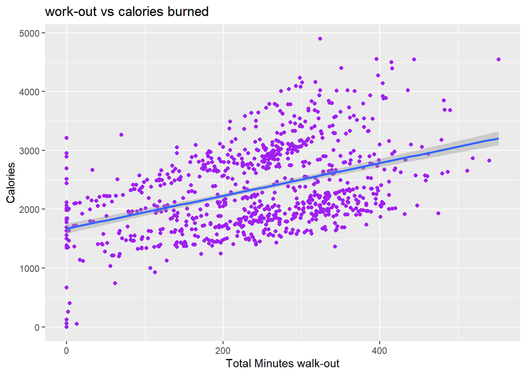

```r
ggplot(dailyActivity_merged,aes(x= totalminutes,y=Calories))+geom_point(color="purple")+geom_smooth(method=lm)+labs(title = "work-out vs calories burned", x="Total Minutes walk-out", y="Calories")
```

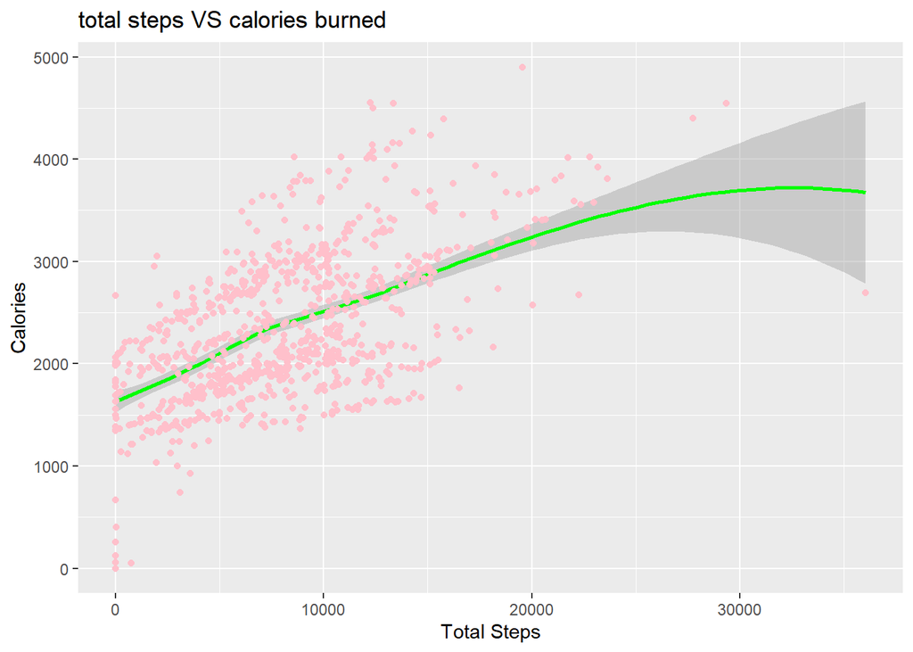

```r
ggplot(dailyActivity_merged,aes(x= TotalSteps,y=Calories))+geom_smooth(color="green")+geom_point(color="pink")+labs(title = "total steps VS calories burned", x="Total Steps", y="Calories")
```

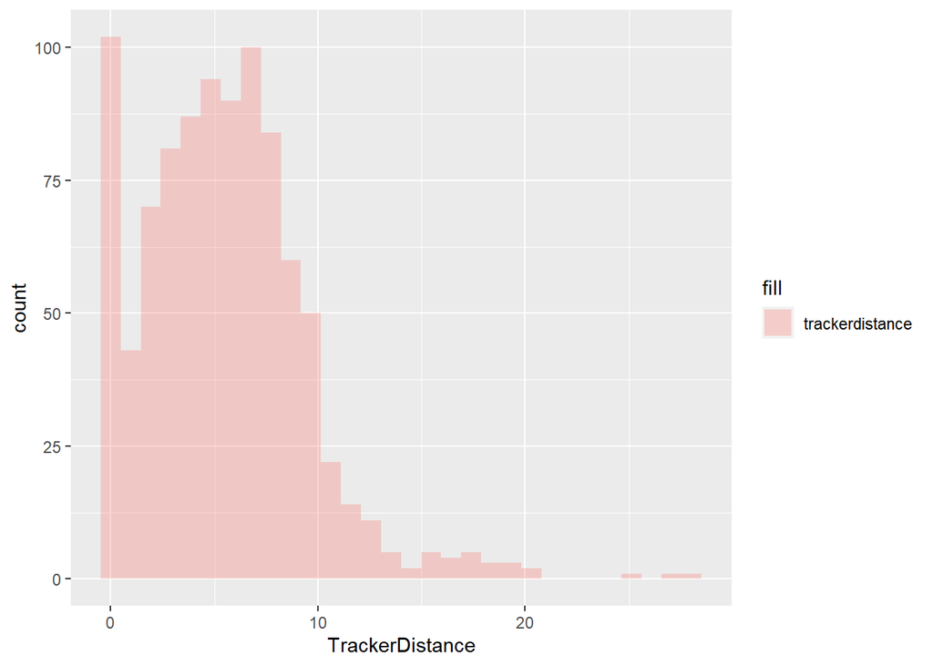

```r
par(mfrow=c(2,2))
  ggplot(dailyActivity_merged,aes(x=TrackerDistance,fill="trackerdistance"))+geom_histogram(alpha=0.3,size=1)
```

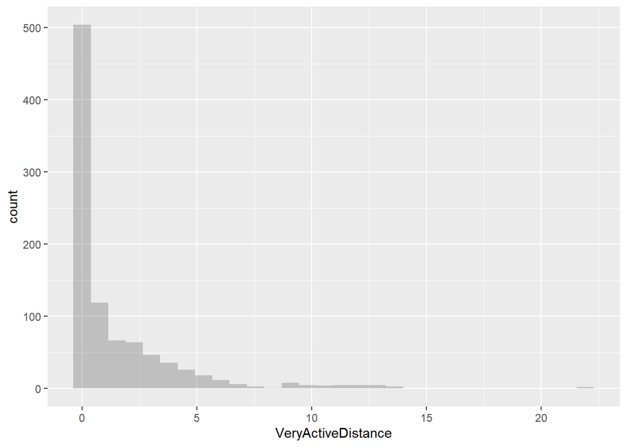

```r
  ggplot(dailyActivity_merged,aes(x=VeryActiveDistance))+geom_histogram(alpha=0.3,size=1)
```

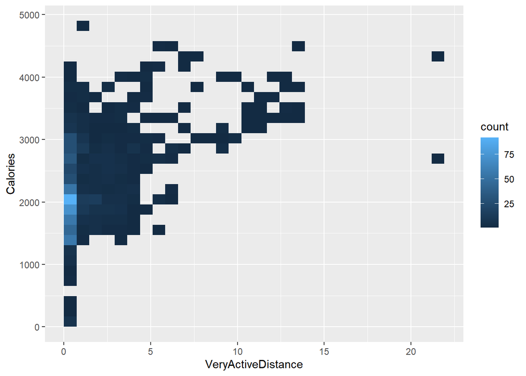

```r
ggplot(dailyActivity_merged,aes(x=VeryActiveDistance,y=Calories))+geom_bin2d()
```

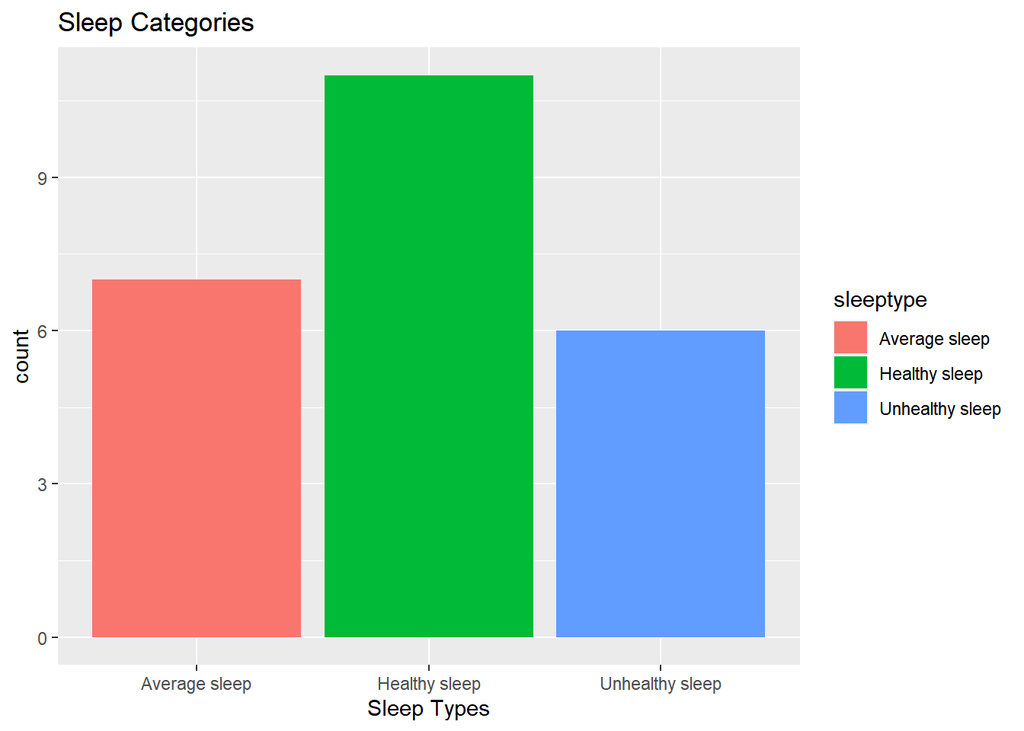

```r
ggplot(data = sleep_categories) +
  geom_bar(mapping = aes(x = sleeptype, fill = sleeptype)) +
  labs(title = "Sleep Categories", x = "Sleep Types")
```

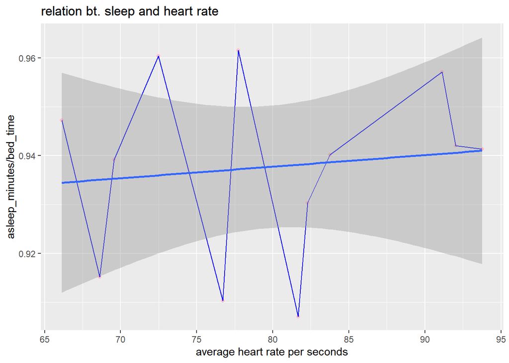

```r
ggplot(hRatesRatio,aes(x=avg_Hrate,y=avg_Ratio))+geom_point(color="pink")+geom_line(color="blue")+geom_smooth(method=lm)+labs(title = "relation bt. sleep and heart rate",x="average heart rate per seconds",y="asleep_minutes/bed_time")
```

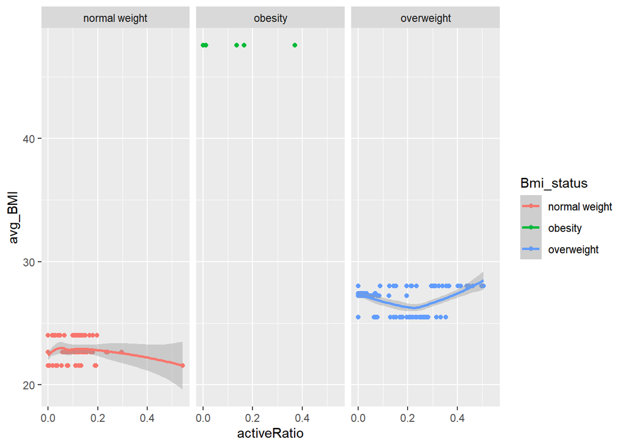

```r
  ggplot(bmiXActive, aes(x=activeRatio,y=avg_BMI,color=Bmi_status))+geom_point()+geom_smooth()+facet_wrap(~Bmi_status)
```

##Key Insights *Most of the people want less time to devout for workout as a result cover less distance overall but we analysed the positive relation between time and calories burned.

- clearly evident,that above last two plots are not to be considered for generalizing the trends of the overall population because of not enough data in “FITbit” which lead to biasedness,low degree of freedom and lack of representation hence, we cant work over the insights these plots provides, even though seemed very important in explaining the trends of the smart devices.